# Lab 04 - Predicting MHV Change

CPP528 Group 05 Fall 2021

Cristian E. Nuno updated by: Amy T. Trumpower, Melissa Millican, Sean Harrington, Joseph Papcznski

November 13, 2021

Today’s date is November 13, 2021.

## Census Variables

### The following factors were chosen to identify gentrification:

- Household Income: An increase in household income may indicate gentrification
- Percentage unemployed: a decrease in unemployment rate may indicate gentrification
- Vacancy Rate: A decrease in vacancy rate may indicate gentrification

```r
#Household Income
hinc.00 <- d$hinc00 * 1.28855
hinc.10 <- d$hinc12
hinc.change <- hinc.10 - hinc.00
p.hinc.change <- hinc.change/hinc.00
p.hinc.growth <- log10(p.hinc.change +1)
d$hinc.change <- p.hinc.change
d$hinc.growth <- p.hinc.growth
```

```r
#% Unemployed
#d$p.unemp[ d$p.unemp > 80 & d$p.unemp <= 1 ] <- NA
#d$p.unemp10[ d$p.unemp10 > 80 & d$unemp.00 <= 1 ] <- NA
unemp.00 <- d$p.unemp
unemp.10 <- d$p.unemp10
unemp.change <- unemp.10 - unemp.00
p.unemp.change <- unemp.change/unemp.00
p.unemp.growth <- log10(p.unemp.change +1)
d$unemp.change<- p.unemp.change
d$unemp.change[d$unemp.change > 80 | d$unemp.change < 1] <- NA
d$unemp.growth  <- p.unemp.growth
d$unemp.growth[d$unemp.growth > 80 | d$unemp.growth < 1] <- NA
```

```r
#Vacancy Rate
vacant.00 <- d$p.vacant
vacant.10 <- d$p.vacant10
vacant.change <- vacant.10 - vacant.00
p.vacant.change <- vacant.change/vacant.00
p.vacant.growth <- log10(p.vacant.change + 1)
d$vacant.change <- p.vacant.change
d$vacant.change[d$vacant.change > 80 | d$vacant.change < 1] <- NA
d$vacant.growth <- p.vacant.growth
d$vacant.growth[d$vacant.growth > 80 | d$vacant.growth < 1] <- NA
```

## Measurement Variables

We looked at the different variables in 2000 and saw some significance between all variables. However after looking at the variables related to growth it appears as though vacancy was not significant to MHV Growth.

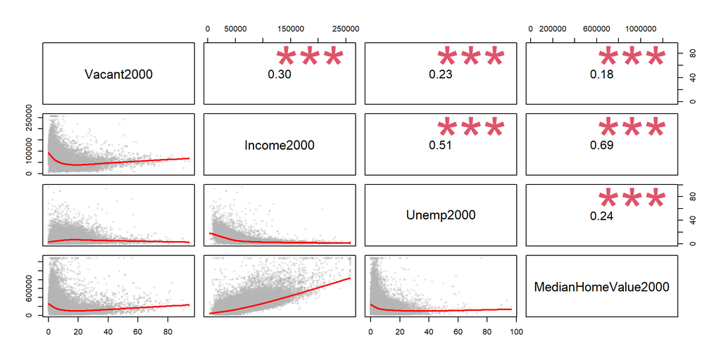

```r
set.seed(1234)

pairs(measurement.1, lower.panel = panel.smooth, upper.panel = panel.cor)
```

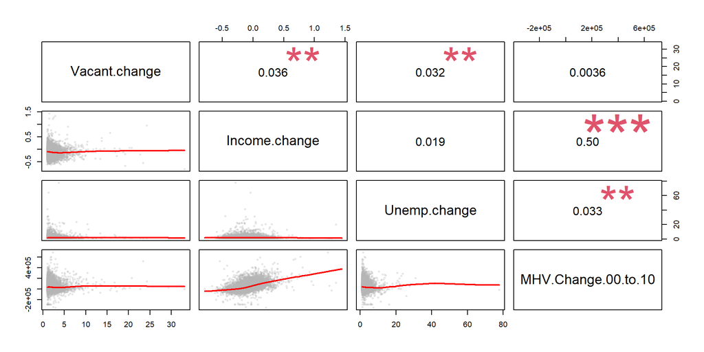

```r
set.seed(1234)

pairs(measurement.2, lower.panel = panel.smooth, upper.panel = panel.cor)
```

## Median Home Value

[figure not shown]

### Descriptives

```
##
## ==========================================================================
## Statistic              Min     Pctl(25) Median   Mean   Pctl(75)    Max
## --------------------------------------------------------------------------
## MedianHomeValue2000   11,167   105,533  154,626 187,171 224,594  1,288,551
## MedianHomeValue2010   9,999    122,700  191,500 246,688 313,600  1,000,001
## MHV.Change.00.to.10 -1,228,651  7,123   35,851  59,985   94,577  1,000,001
## MHV.Growth.00.to.12    -97        6       25      33       49      6,059
## Vacant2000              0         3        5       7       9        99
## Vacant2010              0         5        7      Inf      11       Inf
## Vacant.change           1         1        2       2       2        70
## Vacant.growth           1         1        1       1       1         2
## Unemp2000               0         3        5       6       8        97
## Unemp2010               0         6        9      10       13       79
## Unemp.change            1         1        2       2       3        78
## Unemp.growth            1         1        1       1       1         6
## Income2000            3,220     42,495  56,374  61,420   74,831   257,711
## Income2010            2,499     39,111  53,963  59,603   73,864   250,001
## Income.change           -1        -0      -0      -0       0        30
## Income.growth           -1        -0      -0      -0       0         1
## --------------------------------------------------------------------------
```

### Change in MHV 2000 - 2010

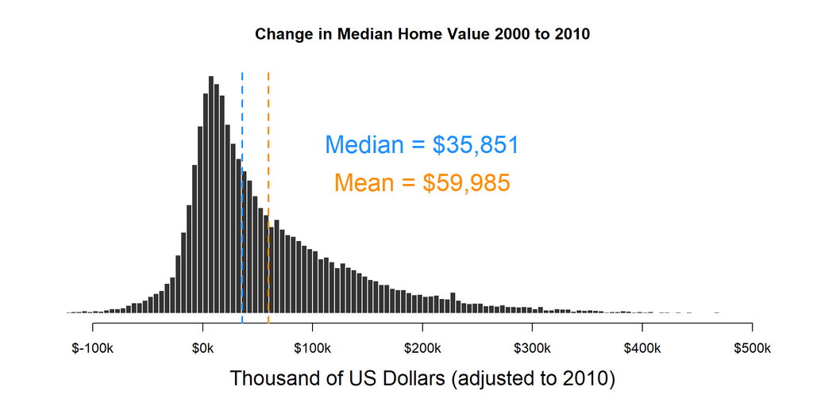

### Percent Change in Median Home Value 2000 to 2010

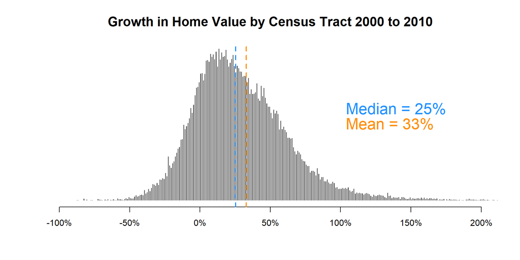

## Metro Level Statistics

```r
cbsa_stats_df %>% head()
```

| cbsaname | metro.mhv.change | metro.mhv.growth |
| --- | --- | --- |
| Abilene, TX | 12667.46 | 2182.0738 |
| Akron, OH | -10633.54 | -887.2800 |
| Albany-Schenectady-Troy, NY | 54412.62 | 4175.8175 |
| Albany, GA | 5546.55 | 645.6258 |
| Albuquerque, NM | 27947.29 | 1848.5316 |
| Alexandria, LA | 23328.67 | 3273.7489 |

#### Metro Demographics

**Vacancy Rate**

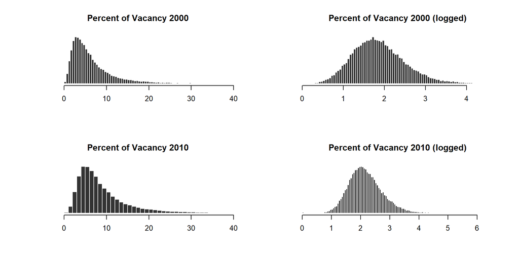

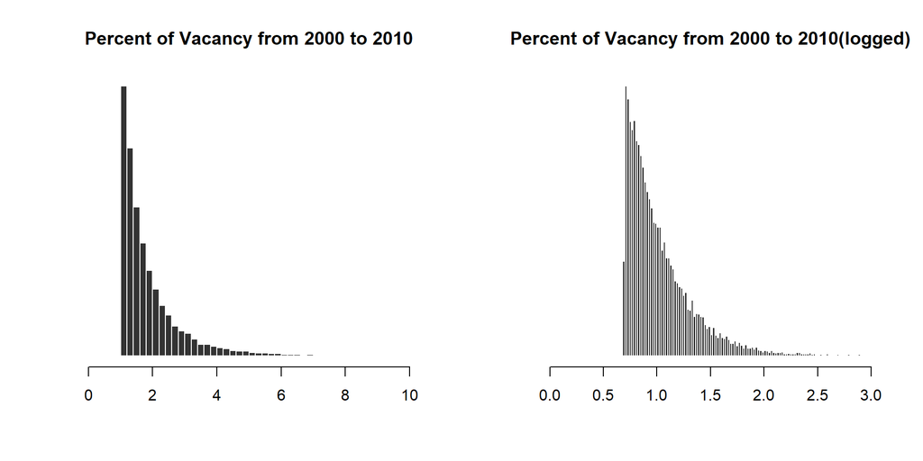

**Unemployment Rate**

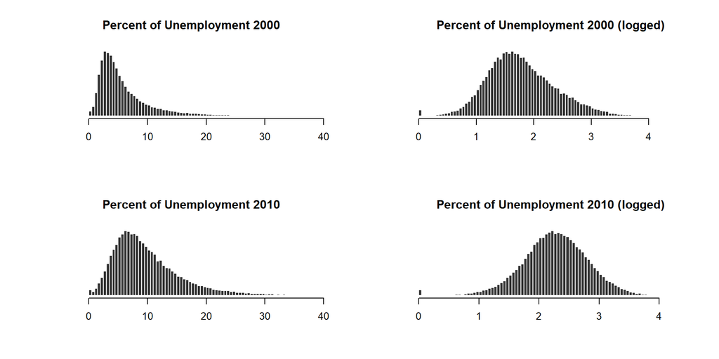

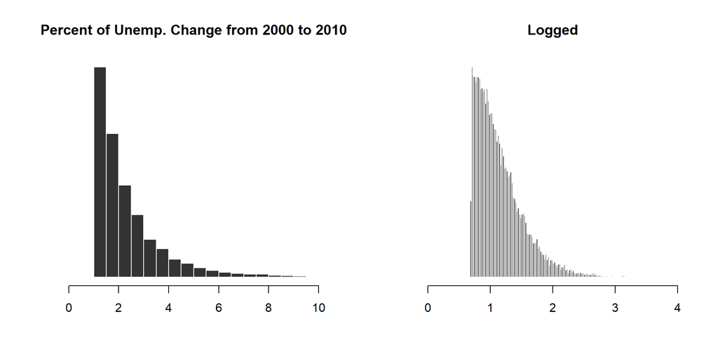

**Household Income**

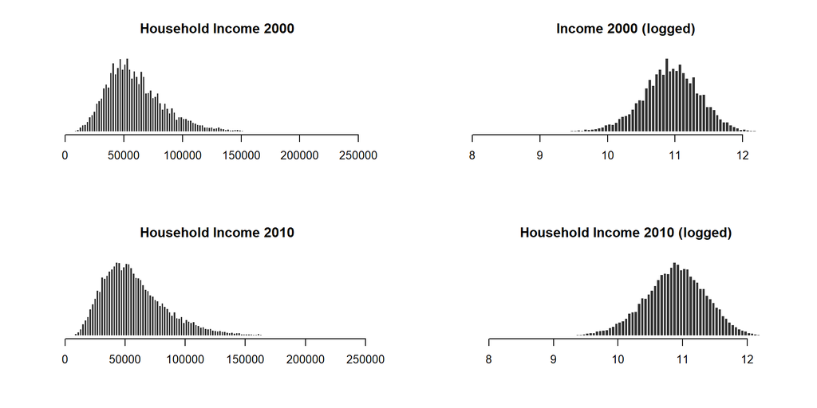

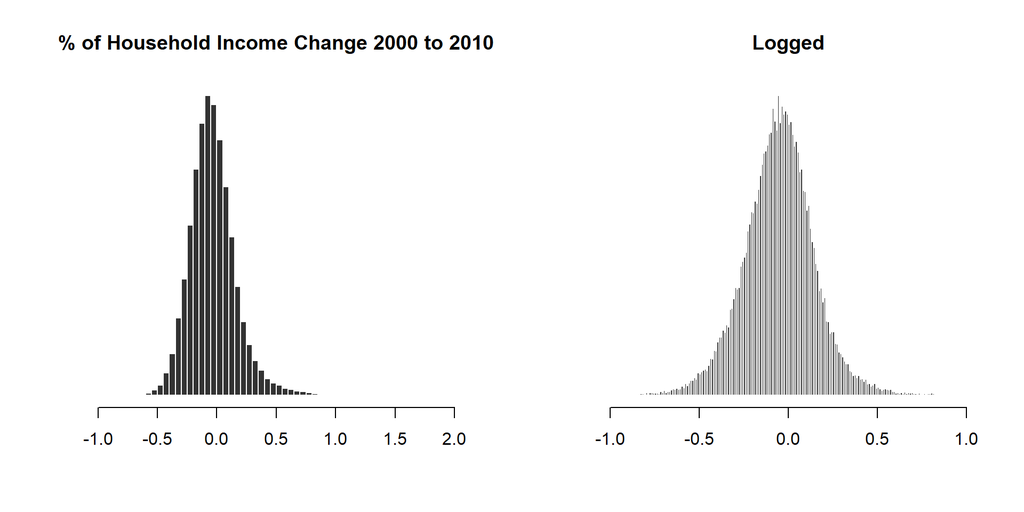

**Correlation between MHV and Vacancy Rates**

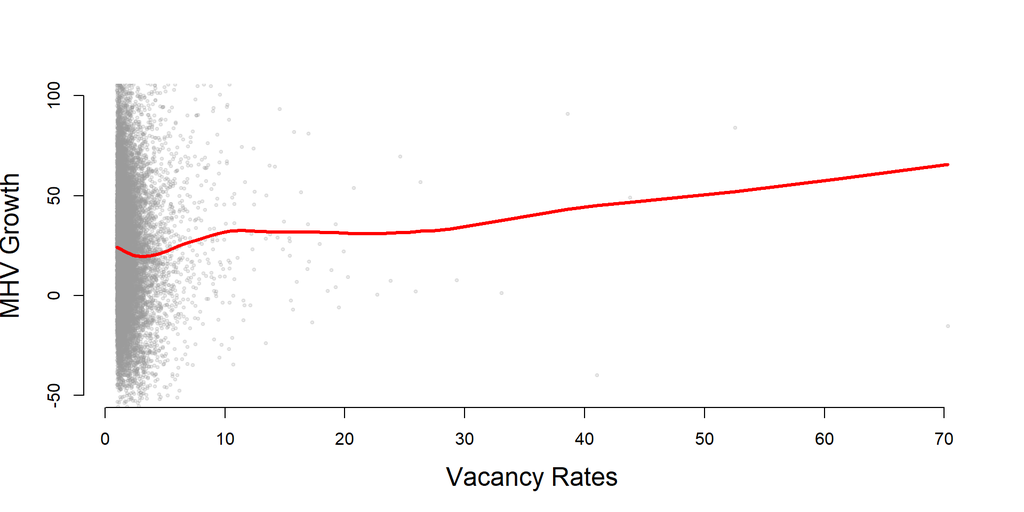

```r
jplot( df$Vacant.change, df$MHV.Growth.00.to.12, ylim=c(-50,100),
       lab1="Vacancy Rates", lab2="MHV Growth" )
```

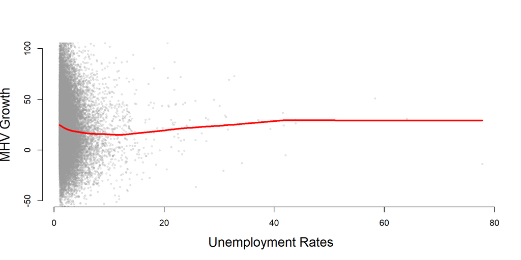

```r
jplot( df$Unemp.change, df$MHV.Growth.00.to.12, ylim=c(-50,100),
       lab1="Unemployment Rates", lab2="MHV Growth" )
```

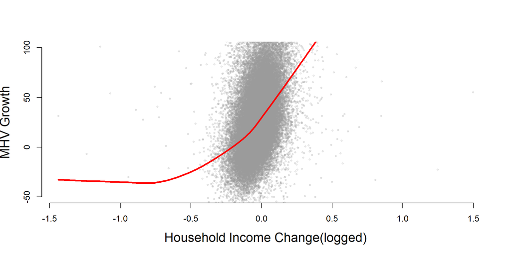

```r
jplot( df$Income.growth, df$MHV.Growth.00.to.12, ylim=c(-50,100),
       lab1="Household Income Change(logged)", lab2="MHV Growth" )
```

## Including regression output

```r
# load necessary packages ----
#library(stargazer)
# load constants ----
#STARGAZER_OUTPUT_TYPE = "html"
# create model ----
reg.data <- d
reg.data$mhv.growth[ reg.data$mhv.growth > 200 ] <- NA
reg.data$p.unemp <- log10( reg.data$unemp.change + 1 )
reg.data$p.vacant <- log10( reg.data$vacant.change + 1 )
reg.data$p.hinc <- log10( reg.data$hinc.change + 1 )
m1 <- lm( mhv.growth ~  p.hinc, data=reg.data )
m2 <- lm( mhv.growth ~  p.unemp, data=reg.data )
m3 <- lm(mhv.growth ~ p.vacant, data = reg.data)
m4 <- lm( mhv.growth ~  p.hinc + p.unemp + p.vacant, data=reg.data )
# display model
stargazer( m1, m2, m3, m4,
           type="text", #S_TYPE,
           digits=2,
           omit.stat = c("rsq","f") )
```

```
##
## ==============================================================================================
##                                                Dependent variable:
##                     --------------------------------------------------------------------------
##                                                     mhv.growth
##                            (1)                (2)                (3)                (4)
## ----------------------------------------------------------------------------------------------
## p.hinc                  152.02***                                                187.05***
##                           (1.47)                                                  (3.90)
##
## p.unemp                                    -14.48***                             -12.33***
##                                              (1.16)                               (1.89)
##
## p.vacant                                                        -2.30              0.19
##                                                                 (2.11)            (2.36)
##
## Constant                 32.84***           30.65***           26.06***          34.96***
##                           (0.14)             (0.61)             (0.99)            (1.43)
##
## ----------------------------------------------------------------------------------------------
## Observations              58,517             25,820             13,783             7,079
## Adjusted R2                0.15               0.01              0.0000             0.25
## Residual Std. Error 32.15 (df = 58515) 31.30 (df = 25818) 35.27 (df = 13781) 27.38 (df = 7075)
## ==============================================================================================
## Note:                                                              *p<0.1; **p<0.05; ***p<0.01
```

## Group Structure

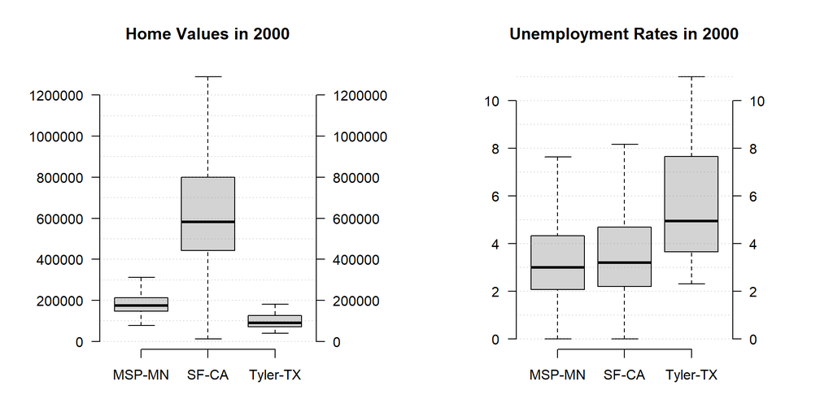

```r
d5 <- filter( d, cbsaname %in%
                c("Tyler, TX",
                  "Minneapolis-St. Paul-Bloomington, MN-WI",
                  "San Francisco-San Mateo-Redwood City,CA") )
d5$cbsaname <- factor( d5$cbsaname, labels=c("MSP-MN","SF-CA","Tyler-TX") )
par( mar=c(4,6,4,6), mfrow=c(1,2) )
plot( d5$cbsaname,  d5$mhv.00, las=1, frame.plot=F, outline=F,
      xlab="", ylab="", main="Home Values in 2000" )
abline( h=seq(0,1200000,100000), lty=3, col=gray(0.5,0.3) )
axis( side=4, las=1 )
plot( d5$cbsaname,  d5$p.unemp, las=1, frame.plot=F, outline=F,
      xlab="", ylab="", main="Unemployment Rates in 2000" )
abline( h=seq(0,15,1), lty=3, col=gray(0.5,0.3) )
axis( side=4, las=1 )
```

**Vacancy 2000 Metro Level**

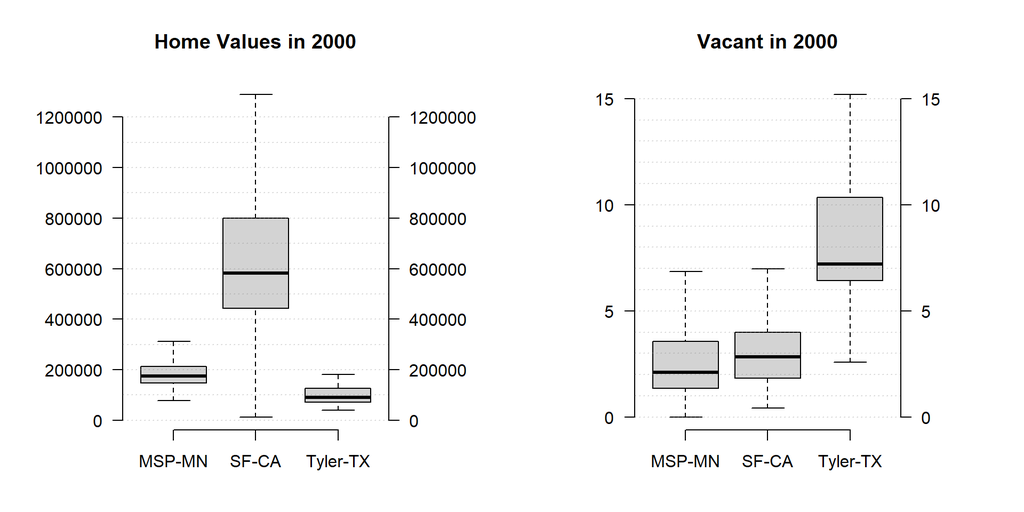

```r
d5 <- filter( d, cbsaname %in%
                c("Tyler, TX",
                  "Minneapolis-St. Paul-Bloomington, MN-WI",
                  "San Francisco-San Mateo-Redwood City,CA") )
d5$cbsaname <- factor( d5$cbsaname, labels=c("MSP-MN","SF-CA","Tyler-TX") )
par( mar=c(4,6,4,6), mfrow=c(1,2) )
plot( d5$cbsaname,  d5$mhv.00, las=1, frame.plot=F, outline=F,
      xlab="", ylab="", main="Home Values in 2000" )
abline( h=seq(0,1200000,100000), lty=3, col=gray(0.5,0.3) )
axis( side=4, las=1 )
plot( d5$cbsaname,  d5$p.vacant, las=1, frame.plot=F, outline=F,
      xlab="", ylab="", main="Vacant in 2000" )
abline( h=seq(0,15,1), lty=3, col=gray(0.5,0.3) )
axis( side=4, las=1 )
```

**Household Income Metro Level**

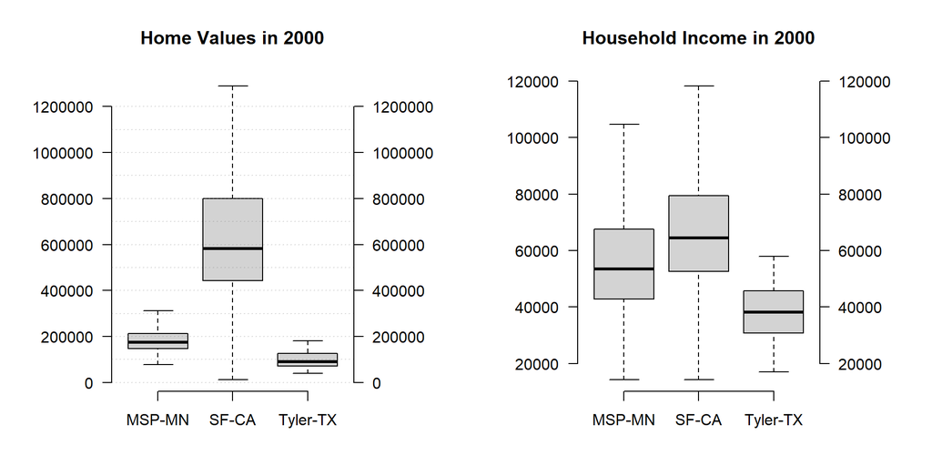

```r
d5 <- filter( d, cbsaname %in%
                c("Tyler, TX",
                  "Minneapolis-St. Paul-Bloomington, MN-WI",
                  "San Francisco-San Mateo-Redwood City,CA") )
d5$cbsaname <- factor( d5$cbsaname, labels=c("MSP-MN","SF-CA","Tyler-TX") )
par( mar=c(4,6,4,6), mfrow=c(1,2) )
plot( d5$cbsaname,  d5$mhv.00, las=1, frame.plot=F, outline=F,
      xlab="", ylab="", main="Home Values in 2000" )
abline( h=seq(0,1200000,100000), lty=3, col=gray(0.5,0.3) )
axis( side=4, las=1 )
plot( d5$cbsaname,  d5$hinc00, las=1, frame.plot=F, outline=F,
      xlab="", ylab="", main="Household Income in 2000" )
abline( h=seq(0,15,1), lty=3, col=gray(0.5,0.3) )
axis( side=4, las=1 )
```

**Health of City 2000 to 2010 Grouped**

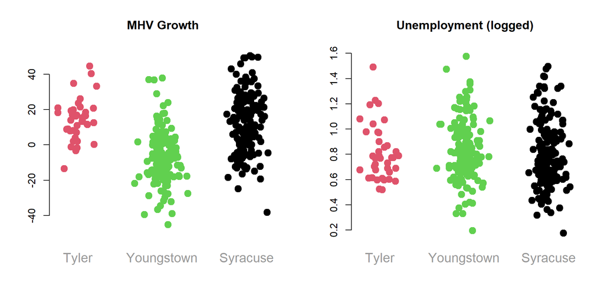

```r
d5 <- filter( d, cbsaname %in%
                c("Tyler, TX",
                  "Youngstown-Warren-Boardman, OH-PA",
                  "Syracuse, NY") )
d5$mhv.growth[ d5$mhv.growth > 200 ] <- NA
d5$p.unemp <- log10( d5$p.unemp + 1 )
x <- rnorm( nrow(d5), 0, 0.1 ) +
     as.numeric( d5$cbsaname == "Tyler, TX" ) +
     2 * as.numeric( d5$cbsaname == "Youngstown-Warren-Boardman, OH-PA" ) +
     3* as.numeric( d5$cbsaname == "Syracuse, NY" )
par( mfrow=c(1,2) )
plot( x, d5$mhv.growth,
      pch=19, cex=1.5, bty = "n",
        col=factor(d5$cbsa),
      ylim=c(-50,50),
      xaxt="n",
      ylab="", xlab="",
      main="MHV Growth")
axis( side=1, at=1:3, labels=c("Tyler","Youngstown","Syracuse"),
      tick=F, col.axis="gray60", cex.axis=1.3 )
plot( x, d5$p.unemp,
      pch=19, cex=1.5, bty = "n",
        col=factor(d5$cbsa),
      # ylim=c(0,40),
      xaxt="n",
      ylab="", xlab="",
      main="Unemployment (logged)")
axis( side=1, at=1:3, labels=c("Tyler","Youngstown","Syracuse"),
      tick=F, col.axis="gray60", cex.axis=1.3 )
```

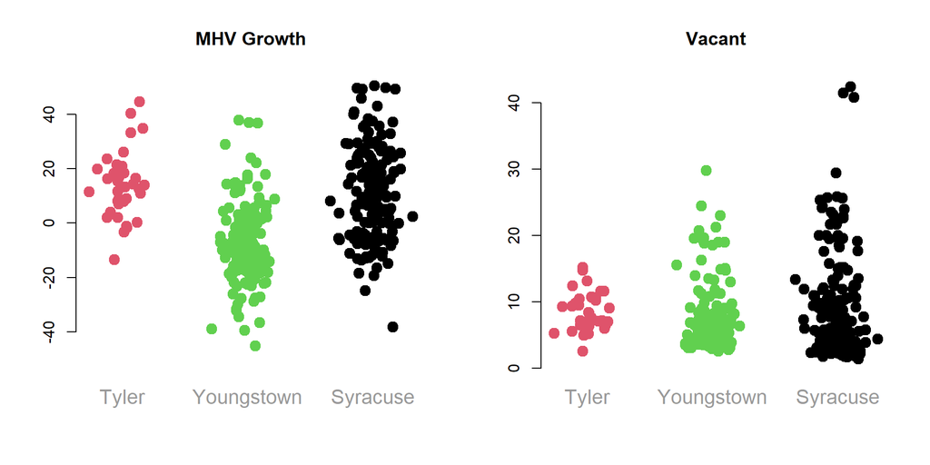

```r
d5 <- filter( d, cbsaname %in%
                c("Tyler, TX",
                  "Youngstown-Warren-Boardman, OH-PA",
                  "Syracuse, NY") )
d5$mhv.growth[ d5$mhv.growth > 200 ] <- NA
#d5$p.vacant <- log10( d5$p.vacant + 1 )
x <- rnorm( nrow(d5), 0, 0.1 ) +
     as.numeric( d5$cbsaname == "Tyler, TX" ) +
     2 * as.numeric( d5$cbsaname == "Youngstown-Warren-Boardman, OH-PA" ) +
     3* as.numeric( d5$cbsaname == "Syracuse, NY" )
par( mfrow=c(1,2) )
plot( x, d5$mhv.growth,
      pch=19, cex=1.5, bty = "n",
        col=factor(d5$cbsa),
      ylim=c(-50,50),
      xaxt="n",
      ylab="", xlab="",
      main="MHV Growth")
axis( side=1, at=1:3, labels=c("Tyler","Youngstown","Syracuse"),
      tick=F, col.axis="gray60", cex.axis=1.3 )
plot( x, d5$p.vacant,
      pch=19, cex=1.5, bty = "n",
        col=factor(d5$cbsa),
      # ylim=c(0,40),
      xaxt="n",
      ylab="", xlab="",
      main="Vacant")
axis( side=1, at=1:3, labels=c("Tyler","Youngstown","Syracuse"),
      tick=F, col.axis="gray60", cex.axis=1.3 )
```

**Baseline metro-level home value growth**

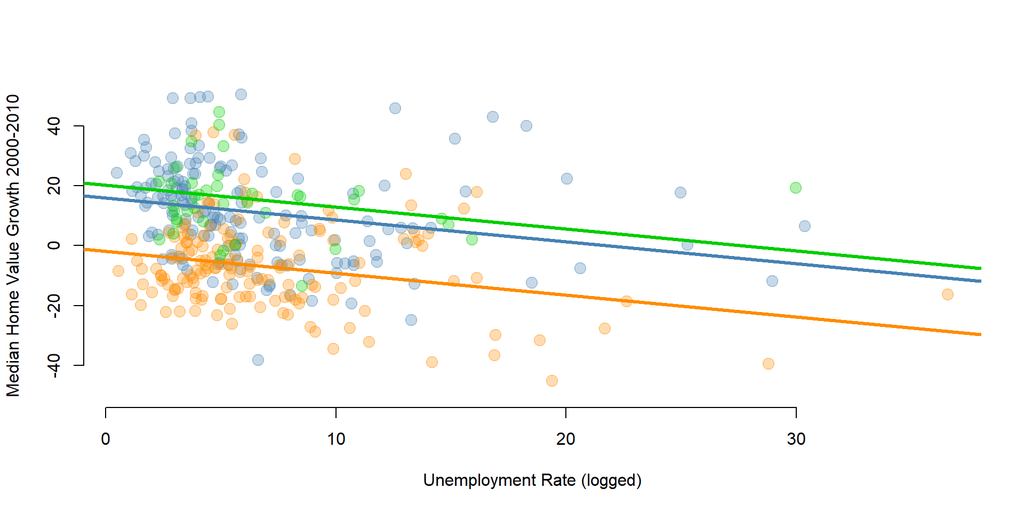

```r
m <- lm( mhv.growth ~ factor(cbsaname) + p.unemp - 1, data=d5 )
b0.syracuse   <- m$coefficients[1]
b0.tyler      <- m$coefficients[2]
b0.youngston  <- m$coefficients[3]
b1            <- m$coefficients[4]
palette( c( "steelblue", "green3", "darkorange"  ) )
palette( adjustcolor( palette(), alpha.f = 0.3 ) )
plot( d5$p.unemp, d5$mhv.growth,
        pch=19, cex=1.5, bty = "n",
        col=factor(d5$cbsa),
      ylim=c(-50,50),
      xlab="Unemployment Rate (logged)",
      ylab="Median Home Value Growth 2000-2010")

abline( b0.syracuse, b1, col="steelblue", lwd=3 )
abline( b0.tyler, b1, col="green3", lwd=3 )
abline( b0.youngston, b1, col="darkorange", lwd=3 )
```

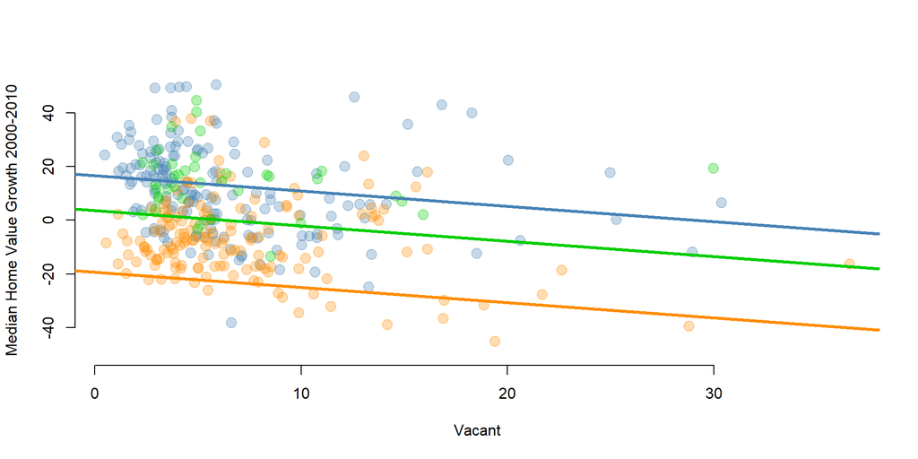

```r
m <- lm( mhv.growth ~ factor(cbsaname) + p.vacant, data=d5 )
b0.syracuse   <- m$coefficients[1]
b0.tyler      <- m$coefficients[2]
b0.youngston  <- m$coefficients[3]
b1            <- m$coefficients[4]
palette( c( "steelblue", "green3", "darkorange"  ) )
palette( adjustcolor( palette(), alpha.f = 0.3 ) )
plot( d5$p.unemp, d5$mhv.growth,
        pch=19, cex=1.5, bty = "n",
        col=factor(d5$cbsa),
      ylim=c(-50,50),
      xlab="Vacant",
      ylab="Median Home Value Growth 2000-2010")

abline( b0.syracuse, b1, col="steelblue", lwd=3 )
abline( b0.tyler, b1, col="green3", lwd=3 )
abline( b0.youngston, b1, col="darkorange", lwd=3 )
```

**Adding fixed effect**

```r
d.reg <- d
d.reg$mhv.growth[ d.reg$mhv.growth > 200 ] <- NA
d.reg$p.unemp <- log10( d.reg$p.unemp + 1 )
# average growth in median home value for the city
d.reg <-
  d.reg %>%
  group_by( cbsaname ) %>%
  mutate( metro.mhv.growth = 100 * median( mhv.growth, na.rm=T ) ) %>%
  ungroup()
m1 <- lm( mhv.growth ~ unemp.change + vacant.change + hinc.change, data=d.reg )
m2 <- lm( mhv.growth ~ unemp.change + vacant.change + hinc.change + metro.mhv.growth, data=d.reg )
m3 <- lm( mhv.growth ~ unemp.change + vacant.change + hinc.change + cbsa, data=d.reg )
stargazer( m1, m2, m3,
           type="text", #S_TYPE,
           digits=2,
           omit.stat = c("rsq","f"),
           omit="cbsa",
           add.lines = list(c("Metro Fixed Effects:", "NO", "NO","YES")) )
```

```
##
## ==========================================================================
##                                       Dependent variable:
##                      -----------------------------------------------------
##                                           mhv.growth
##                             (1)               (2)               (3)
## --------------------------------------------------------------------------
## unemp.change             -0.55***          -0.34***          -0.37***
##                           (0.13)            (0.09)            (0.10)
##
## vacant.change              0.24              0.21              -0.09
##                           (0.21)            (0.15)            (0.16)
##
## hinc.change              94.19***          43.15***          43.43***
##                           (1.89)            (1.50)            (1.54)
##
## metro.mhv.growth                            0.01***
##                                            (0.0001)
##
## Constant                 29.09***           6.21***            -2.81
##                           (0.65)            (0.54)            (4.30)
##
## --------------------------------------------------------------------------
## Metro Fixed Effects:        NO                NO                YES
## Observations               7,079             7,079             7,079
## Adjusted R2                0.26              0.62              0.63
## Residual Std. Error  27.21 (df = 7075) 19.56 (df = 7074) 19.16 (df = 6813)
## ==========================================================================
## Note:                                          *p<0.1; **p<0.05; ***p<0.01
```

**What are the results? Which factor was most important? Did it meet your expectations? Were there any variables that were not significant that you expected to be?**

The results were that two of our three variables ended up being indicators of neighborhood change. Income was the most significant followed by unemployment. We assumed that a change in vacancy influence the median home value due to less people occupying homes, thereby decrease the average price. However, vacancy did not have a significant influence on median home value indicating that additional research is needed to determine why vacancy does not have an impact.